# 542 Deliverable 2

2.11.23

Loading in data and identifying the data types

```r
location ='https://github.com/Drops-of-Jupyter/PUBPOL542/raw/main/'
file ='mergeddeliverable2.csv'
datalink = paste0(location,file)

deliv2data = read.csv(datalink)

str(deliv2data)
```

Setting the random seed for replication purposes

```r
set.seed(999)
```

Adjusting the data to be better fit for analysis

```r
deliv2data[!complete.cases(deliv2data),-c(1,2)]
```

```r
deliv2data=deliv2data[complete.cases(deliv2data),]
```

Looking at value ranges

```r
boxplot(deliv2data[,-c(1,2)])
```

Adjusting scale

```r
deliv2data[,-c(1,2)]=as.data.frame(scale(deliv2data[,-c(1,2)]))
```

Replotting box plot to see value ranges

```r
boxplot(deliv2data[,-c(1,2)])
```

Subsetting the data and checking it worked

```r
dataToCluster=deliv2data[,-c(1,2)]
row.names(dataToCluster)=deliv2data$country
head(dataToCluster)
```

Deciding distance method and computing the distance matrix (using gower measurement)

```r
library(cluster)
distanceMatrix=daisy(x=dataToCluster, metric = "gower")
```

Producing a 2 dimensional map of the data

```r
projectedData = cmdscale(distanceMatrix, k=2)
```

```r
##saving coordinates to original dataframe
deliv2data$dim1 = projectedData[,1]
deliv2data$dim2 = projectedData[,2]
##looking at some of the coordinates
deliv2data[,c('dim1','dim2')][1:10,]
```

```r
##Creating the map
library(ggplot2)
base= ggplot(data=deliv2data,
             aes(x=dim1, y=dim2,
                 label=country))
base + geom_text(size=2)
```

Producing a dendogram as an alternate visualization

```r
hc = hclust(distanceMatrix)
plot(hc,hang = -1,cex=0.5)
```

Computing clustering suggestions to see how many clusters to make

```r
##Agglomerative
library(factoextra)

fviz_nbclust(dataToCluster,
             hcut,
             diss=distanceMatrix,
             method = "gap_stat",
             k.max = 10,
             verbose = F,
             hc_func = "agnes")
##divisive
fviz_nbclust(dataToCluster,
             hcut,
             diss=distanceMatrix,
             method = "gap_stat",
             k.max = 10,
             verbose = F,
             hc_func = "diana")
```

Computing the clusters for both meaasurement types

```r
NumberOfClusterDesired=3

res.agnes= hcut(distanceMatrix,
                k = NumberOfClusterDesired,
                isdiss=TRUE,
                hc_func='agnes',
                hc_method = "ward.D2")

# Hierarchical technique- divisive approach
res.diana= hcut(distanceMatrix,
                k = NumberOfClusterDesired,
                isdiss=TRUE,
                hc_func='diana',
                hc_method = "ward.D2")
```

Saving results to data frame

```r
deliv2data$agn=as.factor(res.agnes$cluster)
deliv2data$dia=as.factor(res.diana$cluster)
```

Verifying ordinality

```r
aggregate(data=deliv2data,
          death.rate~agn,
          FUN=mean)
```

| agn | death.rate |
| --- | --- |
| 1 | -0.4155046 |
| 2 | -0.4619612 |
| 3 | 1.4397635 |

```r
aggregate(data=deliv2data,
          death.rate~dia,
          FUN=mean)
```

reordering to be smallest to greatest

```r
deliv2data_noNA$agn=dplyr::recode_factor(deliv2data_noNAy$agn,
                  `2`='1',`1`='2',`5`='3',`4`='4',`3`='5' ,.ordered = T)
```

```
Error in recode(.x, !!!values, .default = .default, .missing = .missing) :
  object 'deliv2data_noNAy' not found
```

creating silhouettes to see what measurement is best

```r
fviz_silhouette(res.agnes)

##silhouette width =.42
```

```r
fviz_silhouette(res.diana)

##Silhouette width = .5
```

checking for how many countries are poor in each measurement

```r
agnEval=data.frame(res.agnes$silinfo$widths)
diaEval=data.frame(res.diana$silinfo$widths)

agnPoor=rownames(agnEval[agnEval$sil_width<0,])
diaPoor=rownames(diaEval[diaEval$sil_width<0,])
```

```r
diaPoor

#3 countries
```

```r
agnPoor

#3 countries
```

comparing visually

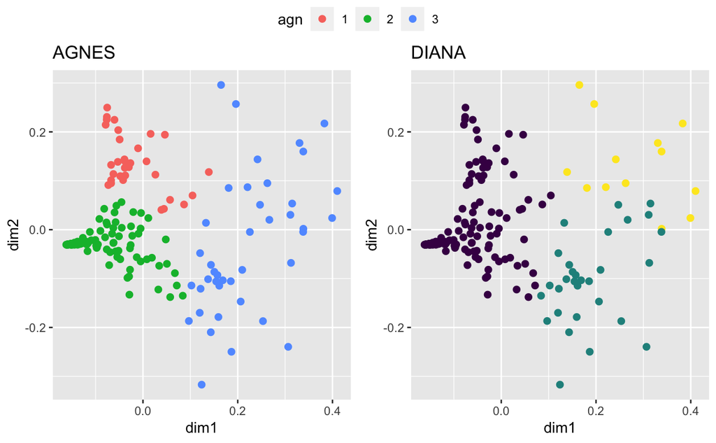

adding labels to the visual

```r
LABELdia=ifelse(deliv2data_noNA$Country%in%diaPoor,deliv2data_noN$Country,"")
```

```
Error in ifelse(deliv2data_noNA$Country %in% diaPoor, deliv2data_noN$Country,  :
  object 'deliv2data_noN' not found
```

```r
library(ggrepel)
diaPlot=diaPlot +
        geom_text_repel(aes(label=LABELdia),
                        max.overlaps=50,
                        min.segment.length =unit(0,'lines'))
```

```r
agnPlot= agnPlot +
         geom_text_repel(aes(label=LABELagn),
                         max.overlaps = 50,
                         min.segment.length = unit(0, 'lines'))
```

```r
ggarrange(agnPlot,
          diaPlot,
          ncol = 2,
          common.legend = T)
```

```r
fviz_dend(res.agnes,
          k=NumberOfClusterDesired,
          cex = 0.45,
          horiz = T,
          main = "AGNES approach")
```

[figure not shown]

Both measurement types are viable options. I believe based on the results of the visual tests conducted, that diana would be the best fitting measurement type.